# COVID-19 Forecast Hub weekly report

Nicholas G Reich, Estee Y Cramer, Martha W Zorn

report generated 2020-09-15, updated 2020-09-17

# Background

This report provides a brief summary of the weekly ensemble forecast from the [COVID-19 Forecast Hub](https://covid19forecasthub.org/) based on forecasts submitted on September 14, 2020. In collaboration with the US CDC, our team aggregates COVID-19 forecasts from dozens of teams around the globe. Typically on Wednesday or Thursday of each week, a summary of the week’s forecasts from the COVID-19 Forecast Hub appear on the [official CDC COVID-19 forecasting page](https://www.cdc.gov/coronavirus/2019-ncov/covid-data/forecasting-us.html).

Every week, teams submit their forecasts to the COVID-19 Forecast Hub. This past week, 54* models were submitted.

Each Monday evening or Tuesday morning, we combine the most recent forecasts from each team into a single “ensemble” forecast of reported COVID-19 cases at the county, state, and national level and deaths at the state and national level. At the moment, we only generate ensemble forecasts for four weeks into the future, as we don’t have reliable evidence that the models are accurate past that horizon.

An archive of weekly reports from the COVID-19 Forecast Hub can be found at [this page](https://covid19forecasthub.org/doc/reports/).

*(updated 9/17/2020 due to error found)

# COVID-19 Mortality Forecasts

## National level

This week, our ensemble combined forecasts from 34 different models.

At the national level, the ensemble model’s best guess is that we will see between 4,600 and 5,000 deaths each week for the next four weeks with around 212,000 deaths by October 10 (Figure 1). For the week ending October 10, the ensemble forecasts that reported COVID-19 deaths in the US will be between 3,000 and 7,100 (95% prediction interval: 2,986 - 7,087).

You can explore the full set of models, including their forecasts for past weeks online at our [interactive forecast visualization](https://viz.covid19forecasthub.org/).

**Figure 1**: Weekly observed and forecasted COVID-19 deaths. Observed data from [JHU CSSE](https://github.com/CSSEGISandData/COVID-19/tree/master/csse_covid_19_data/) and forecasts from the [COVID-19 Forecast Hub](https://covid19forecasthub.org/).

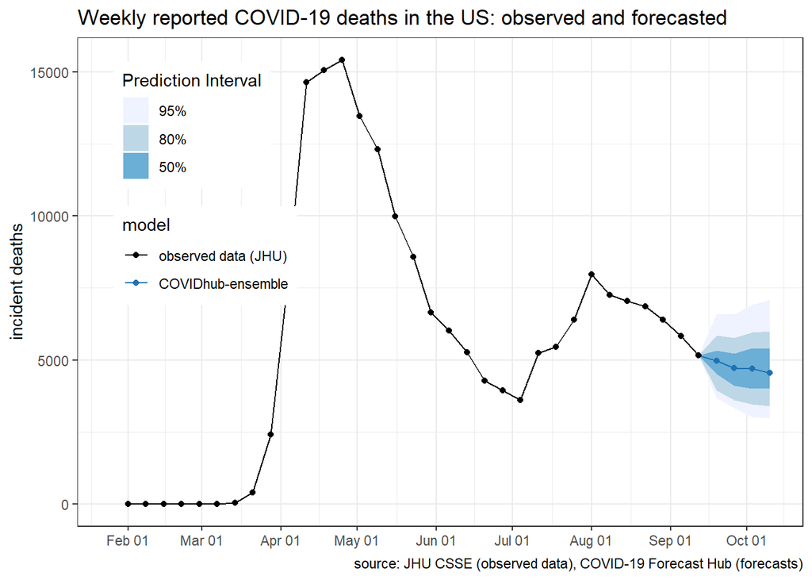

## State-by-state Breakdown

The ensemble model estimates that 21 states and territories of the US have a greater than 50% chance of having more deaths in the next two weeks compared to the past two weeks (Table 1).The model forecasts that 5 states and territories have a greater than 75% chance of an increase over the next two weeks (New Hampshire, Utah, Vermont, American Samoa, Northern Mariana Islands).

The sortable and searchable table below shows the total number of reported COVID-19 deaths at the US level and by state over the last two weeks (ending Saturday, September 12, 2020) and the forecasted counts for the subsequent two weeks (ending September 26, 2020).

| state | Population | Total COVID-19 deaths | COVID-19 deaths, last 2 weeks | COVID-19 deaths, next 2 weeks | Difference |
| --- | --- | --- | --- | --- | --- |
| Oklahoma | 3956971 | 899 | 102 | 112 | 10 |
| Ohio | 11689100 | 4411 | 282 | 289 | 7 |
| Utah | 3205958 | 433 | 26 | 33 | 7 |
| Minnesota | 5639632 | 1958 | 95 | 100 | 5 |
| New Hampshire | 1359711 | 435 | 3 | 8 | 5 |
| Indiana | 6732219 | 3437 | 152 | 155 | 3 |
| South Dakota | 884659 | 183 | 16 | 19 | 3 |
| Connecticut | 3565287 | 4480 | 15 | 17 | 2 |
| Delaware | 973764 | 613 | 9 | 11 | 2 |
| Pennsylvania | 12801989 | 7829 | 173 | 175 | 2 |

[output cut: 47 more lines]

The sortable and searchable table below shows the total number of reported COVID-19 deaths at the US level and by state as of Saturday, September 12, 2020 (“Total COVID-19 Deaths”) as well as the rate of reported COVID-19 deaths in the population (standardized per 100,000 population) over the last two weeks and over the next two weeks. Looking at the rates allows for easier comparison across states, where you can see which states have had or are predicted to have propoportionally higher rates in comparison to other states. These tables calculate an average daily number of deaths per 100,000 population across the last two weeks (ending Saturday, September 12, 2020) and forecasted for the following two weeks (ending September 26, 2020).

| state | Population | Total COVID-19 deaths | Daily deaths per 100k, last 2 weeks | Daily deaths per 100k, next 2 weeks | Death rate difference |
| --- | --- | --- | --- | --- | --- |
| New Hampshire | 1359711 | 435 | 0.016 | 0.042 | 0.026 |
| South Dakota | 884659 | 183 | 0.129 | 0.153 | 0.024 |
| Oklahoma | 3956971 | 899 | 0.184 | 0.202 | 0.018 |
| Utah | 3205958 | 433 | 0.058 | 0.074 | 0.016 |
| Delaware | 973764 | 613 | 0.066 | 0.081 | 0.015 |
| Vermont | 623989 | 58 | 0 | 0.011 | 0.011 |
| Minnesota | 5639632 | 1958 | 0.12 | 0.127 | 0.007 |
| Maine | 1344212 | 135 | 0.016 | 0.021 | 0.005 |
| Ohio | 11689100 | 4411 | 0.172 | 0.177 | 0.005 |
| Connecticut | 3565287 | 4480 | 0.03 | 0.034 | 0.004 |

[output cut: 47 more lines]

This report was reproducibly and dynamically generated using RMarkdown. The code for the report can be found [here](https://github.com/reichlab/covid19-forecast-hub/tree/master/code/reports).